# Bayesian Analysis of Rent Prices in Indian cities

Simone Zagaria, 2145389

2025-06-21

# Introduction

Housing affordability has become a critical problems in urban centers, where rental prices are becoming very high and fluctuate due to various factors such as property size, number of rooms, location, and furnishing status.

In this project, our objective is to construct a **Bayesian Hierarchical Model** to account for this variability at multiple levels. In particular, we explored three different model specifications and assessed their performance and convergence to try and capture the best distribution of rent prices. The best model will also be compared to a corresponding frequentist model to assess their differences.

This research aims to assist individuals seeking for rental housing by identifying the key factors that influence rent prices. By understanding these factors, these people can make more informed decisions and find the most cost-effective options.

## Dataset

In particular, it includes:

- **BHK**: Number of Bedrooms, Hall, and Kitchen in the property.
- **Rent**: Monthly rental price of the property (in Indian Rupees).
- **Bathroom**: Number of bathrooms available in the property.
- **Size**: Area of the property in square feet.
- **Floor**: The floor number where the property is located and the total number of floors in the building.
- **City**: The city in which the property is located.
- **Furnishing Status**: Indicates whether the property is Furnished, Semi-Furnished, or Unfurnished.
- **Area Type**: Type of area measurement used. (Super Area, Carpet Area, or Built Area)
- **Tenant Preferred**: The type of tenants preferred by the owner or agent.
- **Point of Contact**: The person or entity to contact for further details about the property.

The dataset is publicly available on Kaggle: https://www.kaggle.com/datasets/iamsouravbanerjee/house-rent-prediction-dataset.

```r
# Loading the data
df <- read.csv(r"(C:\Users\nephr\Desktop\SDS2 Project\1 - House Pricings\SDS2_Zagaria\House_Rent_Dataset.csv)")
head(df)
```

|  | Posted.On | BHK | Rent | Size | Floor | Area.Type | City | Furnishing.Status | Tenant.Preferred | Bathroom | Point.of.Contact |
| --- | --- | --- | --- | --- | --- | --- | --- | --- | --- | --- | --- |
| 1 | 2022-05-18 | 2 | 10000 | 1100 | Ground out of 2 | Super Area | Kolkata | Unfurnished | Bachelors/Family | 2 | Contact Owner |
| 2 | 2022-05-13 | 2 | 20000 | 800 | 1 out of 3 | Super Area | Kolkata | Semi-Furnished | Bachelors/Family | 1 | Contact Owner |
| 3 | 2022-05-16 | 2 | 17000 | 1000 | 1 out of 3 | Super Area | Kolkata | Semi-Furnished | Bachelors/Family | 1 | Contact Owner |
| 4 | 2022-07-04 | 2 | 10000 | 800 | 1 out of 2 | Super Area | Kolkata | Unfurnished | Bachelors/Family | 1 | Contact Owner |
| 5 | 2022-05-09 | 2 | 7500 | 850 | 1 out of 2 | Carpet Area | Kolkata | Unfurnished | Bachelors | 1 | Contact Owner |
| 6 | 2022-04-29 | 2 | 7000 | 600 | Ground out of 1 | Super Area | Kolkata | Unfurnished | Bachelors/Family | 2 | Contact Owner |

## Preprocessing and Data Cleaning

Before Analyzing the data, we’ll clean and preprocess the dataset. First, we ensure that there are no NaN values:

```r
# Count missing values
null_count <- colSums(is.na(df))
null_count
```

```
##         Posted.On               BHK              Rent              Size
##                 0                 0                 0                 0
##             Floor         Area.Type              City Furnishing.Status
##                 0                 0                 0                 0
##  Tenant.Preferred          Bathroom  Point.of.Contact
##                 0                 0                 0
```

The dataset appears to have no missing values. Next, we remove the irrelevant columns and we convert into categorical factors the columns with a limited number of unique values. We also formatted the ‘Floor’ column in numeric format to allow analyses.

```r
# Remove useless column
df <- df[, !(names(df) %in% c("Posted.On"))]

# Create a copy of the original dataset to not modify the original
df_clean <- df

# Convert to factors with textual labels
df_clean$Furnishing.Status   <- factor(df_clean$Furnishing.Status)
df_clean$Tenant.Preferred    <- factor(df_clean$Tenant.Preferred)
df_clean$Point.of.Contact    <- factor(df_clean$Point.of.Contact)
df_clean$Area.Type           <- factor(df_clean$Area.Type)
df_clean$City                <- factor(df_clean$City)

# Clean the "Floor" variable (Ground = 0, take only the first number)
df_clean$Floor[grepl("Ground", df_clean$Floor, ignore.case = TRUE)] <- "0"
df_clean$Floor <- as.integer(sub("([0-9]+).*", "\\1", df_clean$Floor))

df_clean <- df_clean[!is.na(df_clean$Floor), ]
```

Below is the cleaned version of the dataset:

```r
head(df_clean)
```

|  | BHK | Rent | Size | Floor | Area.Type | City | Furnishing.Status | Tenant.Preferred | Bathroom | Point.of.Contact |
| --- | --- | --- | --- | --- | --- | --- | --- | --- | --- | --- |
| 1 | 2 | 10000 | 1100 | 0 | Super Area | Kolkata | Unfurnished | Bachelors/Family | 2 | Contact Owner |
| 2 | 2 | 20000 | 800 | 1 | Super Area | Kolkata | Semi-Furnished | Bachelors/Family | 1 | Contact Owner |
| 3 | 2 | 17000 | 1000 | 1 | Super Area | Kolkata | Semi-Furnished | Bachelors/Family | 1 | Contact Owner |
| 4 | 2 | 10000 | 800 | 1 | Super Area | Kolkata | Unfurnished | Bachelors/Family | 1 | Contact Owner |
| 5 | 2 | 7500 | 850 | 1 | Carpet Area | Kolkata | Unfurnished | Bachelors | 1 | Contact Owner |
| 6 | 2 | 7000 | 600 | 0 | Super Area | Kolkata | Unfurnished | Bachelors/Family | 2 | Contact Owner |

# Exploratory Data Analysis

Next, we perform Exploratory Data Analysis (EDA) to understand the structure and distribution of the data and to identify patterns.

First, we constructed boxplots to observe the distribution of the numerical variables in the dataset. These visualizations allow to notice immeditatly tendencies, variability, and the presence of outliers:

```r
# List of numerical variables
num_vars <- c("Rent", "Size", "Floor", "BHK", "Bathroom")

# Create a list of interactive boxplots
plots <- lapply(num_vars, function(var) {
  p <- ggplot(df_clean, aes(x = "", y = get(var))) +
    geom_boxplot(fill = "#2196F3", color = "#003366") +
    theme_minimal() +
    labs(title = var, y = var)

  ggplotly(p)
})

htmltools::tagList(plots)
```

[interactive chart not shown]

Starting with **Rent**, we observe a strong right-skewed distribution. The majority of rental prices are concentrated in the lower range, while a significant number of extreme outliers indicate the presence of properties with much higher rents. This suggests that this variable might need a transformation to reduce the influence of those extreme values. **Size** shows a similar pattern, with a concentration around smaller property sizes and several large outliers. Like Rent, this too needs a transformation.

The **Floor**, **BHK** and **Bathroom** variables, on the other hand show a more balanced spread. In particular, Most listings appear to be between the ground and the 6th floor, and only few outliers above the 10th floor, have 1 to 3 bathrooms and 1 to 3 BHK rooms. All those 3 variables show a clear and interpretable structure, therefore they *do not need transformation* and can be *straightforwardly included* in the Bayesian model.

Let’s also plot the histogram of Rent and Size to further examine their skewness and identify the presence of extreme values:

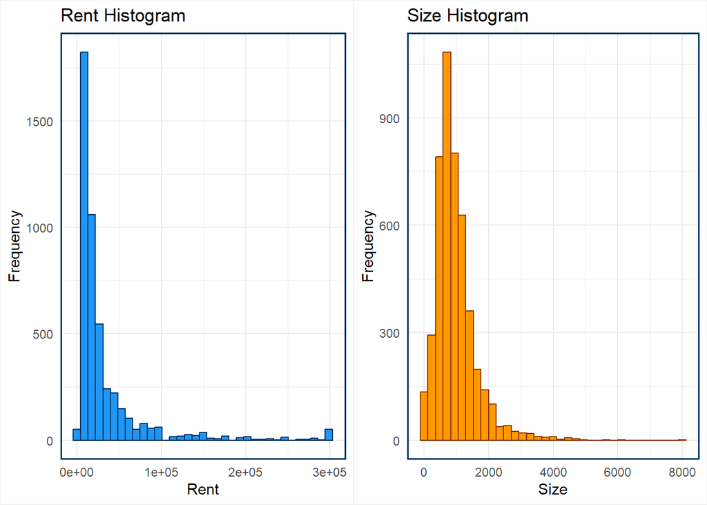

```r
# Rent histogram
h1 <- ggplot(df_clean, aes(x = Rent)) +
  geom_histogram(bins = 35, fill = "#2196F3", color = "#003366") +
  labs(title = "Rent Histogram", x = "Rent", y = "Frequency") +
  theme_minimal() +
  theme(
    plot.background = element_rect(fill = "#FFFFFF", color = "#F0F0F0"),
    panel.border = element_rect(color = "#003366", fill = NA, size = 1)
  )

# Size histogram
h2 <- ggplot(df_clean, aes(x = Size)) +
  geom_histogram(bins = 35, fill = "#FF9800", color = "#8a3601") +
  labs(title = "Size Histogram", x = "Size", y = "Frequency") +
  theme_minimal() +
  theme(
    plot.background = element_rect(fill = "#FFFFFF", color = "#F0F0F0"),
    panel.border = element_rect(color = "#003366", fill = NA, size = 1)
  )

grid.arrange(h1, h2, ncol = 2)
```

From this plots we can confirm that both distributions present a pronounced right skewness and need appropriate preprocessing to improve the performance and interpretability of the hierarchical Bayesian model.

Next, we wanted to explore if effectively rental prices vary across different cities and how they vary in relation to the number of rooms:

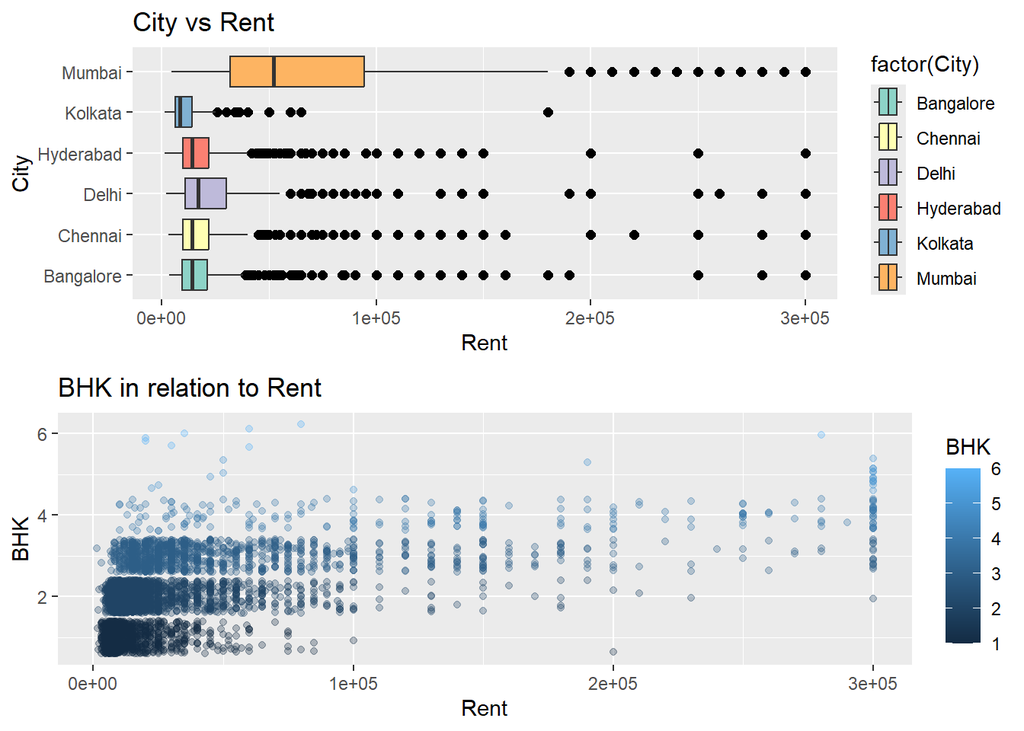

```r
# Boxplot for the "City" variable with respect to rent
subur <- ggplot(df_clean, aes(x=Rent, y=factor(City), fill=factor(City))) +
  geom_boxplot(outlier.colour="black", outlier.shape=16,
               outlier.size=2, notch=FALSE) +
  labs(title="City vs Rent", x="Rent", y="City") +
  scale_y_discrete(guide = guide_axis(check.overlap = TRUE)) +
  scale_fill_brewer(palette = "Set3")

# Scatter plot Rent vs BHK
room_s <- ggplot(df_clean, aes(x=Rent, y=BHK, color=BHK, na.rm=TRUE)) +
  geom_point(na.rm=TRUE, position="jitter", alpha=0.3) +
  labs(title="BHK in relation to Rent", x="Rent", y="BHK") +
  scale_x_continuous(guide = guide_axis(check.overlap = TRUE)) +
  scale_y_continuous(guide = guide_axis(check.overlap = TRUE))

grid.arrange(subur, room_s)
```

Finally, before passing to the data transformation and the models, we measure the correlation between the numerical values:

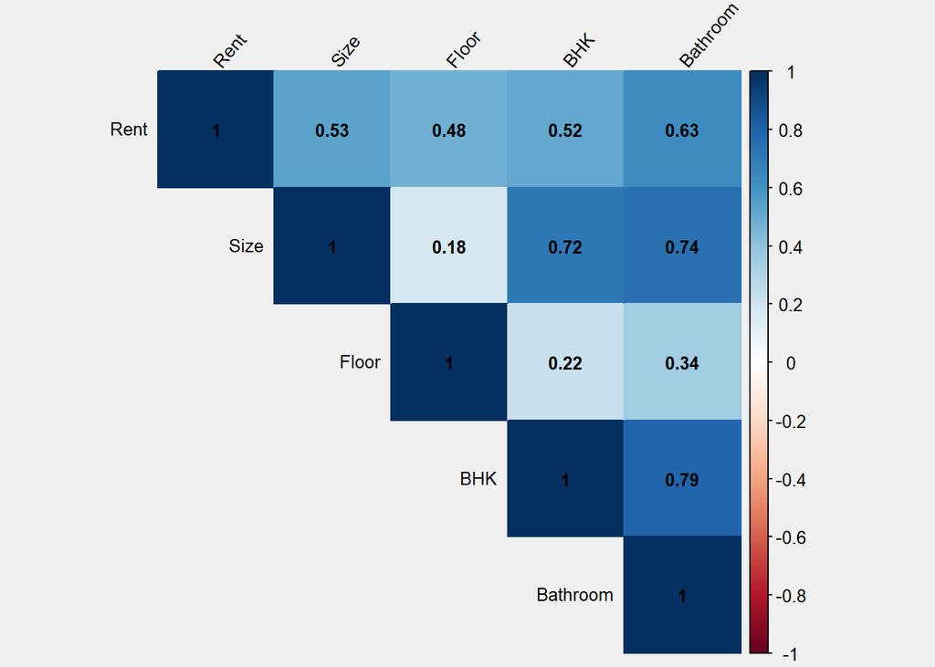

```r
# Selecting only numerical variables
features <- c("Rent","Size","Floor","BHK","Bathroom")

# Filter the dataset
cor_data <- dplyr::select(df_clean, all_of(features))

# Computing the correlation matrix
cor_matrix <- cor(cor_data, use = "complete.obs")

par(bg = "#F0F0F0")
corrplot(cor_matrix, method = "color", type = "upper",
         tl.col = "black", tl.srt = 50,
         addCoef.col = "black", number.cex = 0.8,
         tl.cex = 0.8)
```

From this plot,we observed that some variables could pose challenges for the model due to their high correlation. In particular, those variables are **BHK**, **Bathroom** and **Size**. Since Size plays a key role in explaining rental price, and by experimenting we understood that retaining it did not significantly affect model convergence or stability, we decided to keep it as a predictor. However, to reduce redundancy, we decided to combine the fields BHK and Bathroom into a single variable called **TotalRooms**, as we will see in the next section.

# Data Transformation

To address the strong right-skewness observed in the Rent and Size variables, I applied the Box–Cox transformation. Unlike fixed transformations such as the logarithm or square root, the Box–Cox method allows for a data-driven selection of the transformation parameter (λ) that maximizes the likelihood of normality. This flexibility makes it especially useful when the appropriate transformation is not obvious or when the variables exhibit non-standard skewness.

In particular, the log transformation is equivalent to the Box–Cox transformation with λ = 0. However, enforcing a log transformation without testing whether it’s optimal can lead to suboptimal normalization, especially when the data deviates from strict log-normality. The Box–Cox method empirically identifies the best λ within a specified range—in this case, from -2 to 2—ensuring that the transformation is tailored to the actual distribution of each variable.

Before applying the Box–Cox transformation, I evaluated the adequacy of a simple linear model using the untransformed Rent and Size variables. Q-Q Plot and Residuals vs Fitted values plot were used to assess the assumptions of normality and homoscedasticity of residuals.

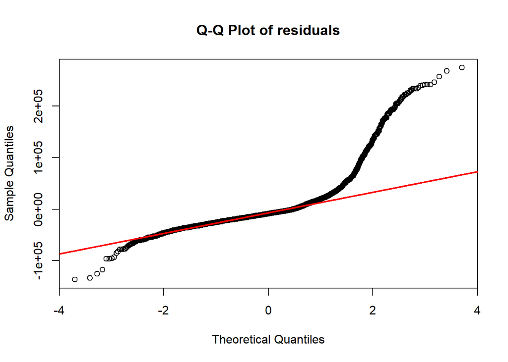

```r
# Simple linear model with Box–Cox transformed Rent and Size
residuals_bc <- lm(Rent ~ Size, data = df_clean)$residuals

# Q-Q plot of the residuals
qqnorm(residuals_bc, main = "Q-Q Plot of residuals")
qqline(residuals_bc, col = "red", lwd = 2)
```

In the Q-Q plot of the residuals, we observe a pronounced deviation from the red reference line, especially in both tails of the distribution. The curvature indicates that the residuals are not normally distributed. In particular, the heavy tails suggest the presence of extreme values and skewness in the residuals, which violates the assumption of Gaussian errors and can severely impact inference and prediction accuracy, as expected from the previous plots.

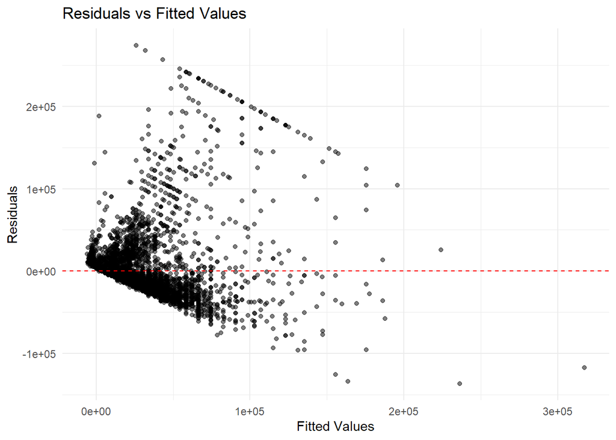

```r
# Linear model: transformed rent (Box–Cox) as a function of transformed size
lm_model <- lm(Rent ~ Size, data = df_clean)

# Extract residuals and fitted values
residuals_bc <- residuals(lm_model)
fitted_bc <- fitted(lm_model)

ggplot(df_clean, aes(x = fitted_bc, y = residuals_bc)) +
  geom_point(alpha = 0.5) +
  geom_hline(yintercept = 0, linetype = "dashed", color = "red") +
  labs(
    title = "Residuals vs Fitted Values",
    x = "Fitted Values",
    y = "Residuals"
  ) +
  theme_minimal()
```

The residuals vs fitted values plot shows a clear pattern of heteroscedasticity: the spread of residuals increases with the fitted values, forming a cone-like shape. This means that the variance of the residuals is not constant across the range of predicted values — another key violation of linear model assumptions. Furthermore, the residuals appear to cluster in a non-random fashion, suggesting potential model misspecification. Thus this implies there is not homodasticity.

Thus, we apply the Cox Box transformation to the mentioned fields:

```r
# Box–Cox per Size
bc_size <- boxcox(Size ~ 1, data = df_clean, lambda = seq(-2, 2, 0.1), plotit = FALSE)
lambda_size <- bc_size$x[which.max(bc_size$y)]

df_clean$Size_bc <- (df_clean$Size^lambda_size - 1) / lambda_size


# Box–Cox per Rent
bc_rent <- boxcox(Rent ~ 1, data = df_clean, lambda = seq(-2, 2, 0.1), plotit = FALSE)
lambda_rent <- bc_rent$x[which.max(bc_rent$y)]

df_clean$Rent_bc <- (df_clean$Rent^lambda_rent - 1) / lambda_rent
```

and let’s observe the changes to the distributions:

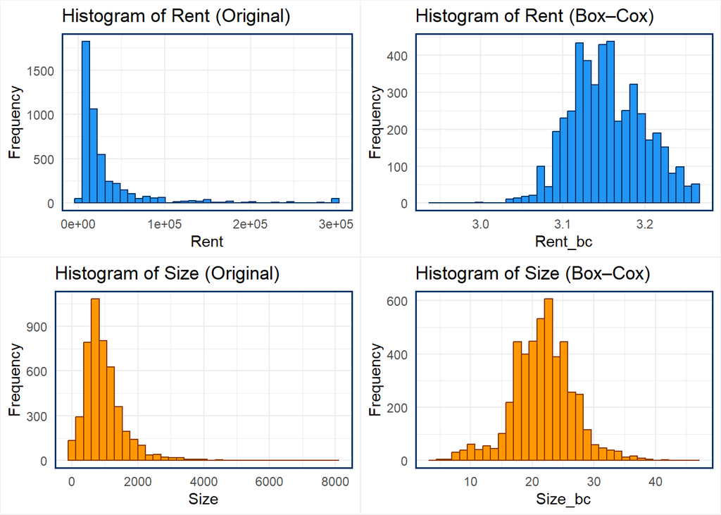

```r
# Rent
h1 <- ggplot(df_clean, aes(x = Rent)) +
  geom_histogram(bins = 35, fill = "#2196F3", color = "#003366") +
  labs(title = "Histogram of Rent (Original)", x = "Rent", y = "Frequency") +
  theme_minimal() +
  theme(
    plot.background = element_rect(fill = "#FFFFFF", color = "#F0F0F0"),
    panel.border = element_rect(color = "#003366", fill = NA, size = 1)
  )

# Rent bc
h1_bc <- ggplot(df_clean, aes(x = Rent_bc)) +
  geom_histogram(bins = 35, fill = "#2196F3", color = "#003366") +
  labs(title = "Histogram of Rent (Box–Cox)", x = "Rent_bc", y = "Frequency") +
  theme_minimal() +
  theme(
    plot.background = element_rect(fill = "#FFFFFF", color = "#F0F0F0"),
    panel.border = element_rect(color = "#003366", fill = NA, size = 1)
  )




# Size
h2 <- ggplot(df_clean, aes(x = Size)) +
  geom_histogram(bins = 35, fill = "#FF9800", color = "#8a3601") +
  labs(title = "Histogram of Size (Original)", x = "Size", y = "Frequency") +
  theme_minimal() +
  theme(
    plot.background = element_rect(fill = "#FFFFFF", color = "#F0F0F0"),
    panel.border = element_rect(color = "#003366", fill = NA, size = 1)
  )

# Size bc
h2_bc <- ggplot(df_clean, aes(x = Size_bc)) +
  geom_histogram(bins = 35, fill = "#FF9800", color = "#8a3601") +
  labs(title = "Histogram of Size (Box–Cox)", x = "Size_bc", y = "Frequency") +
  theme_minimal() +
  theme(
    plot.background = element_rect(fill = "#FFFFFF", color = "#F0F0F0"),
    panel.border = element_rect(color = "#003366", fill = NA, size = 1)
  )

grid.arrange(h1, h1_bc, h2, h2_bc, ncol = 2)
```

We observe already that the transformed variables are now much more symmetrically distributed. The right skew is significantly reduced, and the overall shape is closer to a normal distribution. This makes the variable far more suitable for modeling with Gaussian errors.

However, we also want to re-evaluated the residual diagnostics to assess whether the transformation improved the distributional properties of the model residuals. For this, I performed again the two diagnostic checks:

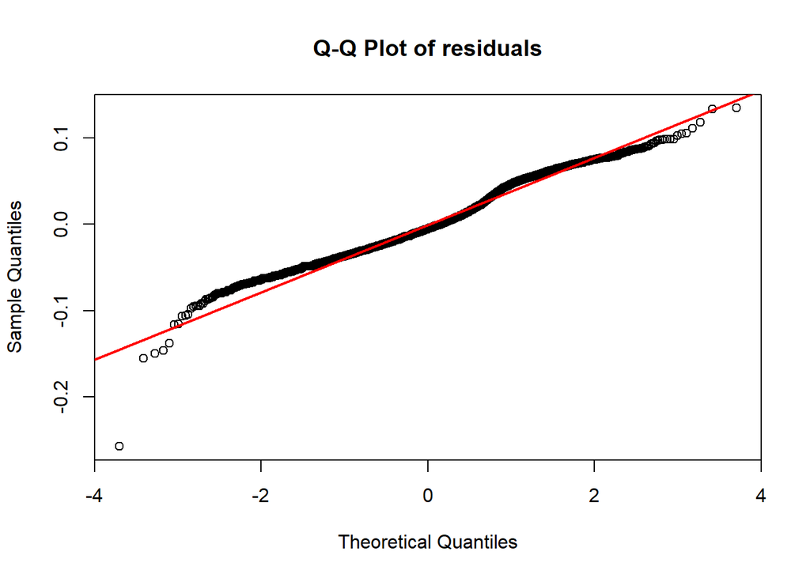

```r
# Simple linear model with Box–Cox transformed Rent and Size
residuals_bc <- lm(Rent_bc ~ Size_bc, data = df_clean)$residuals

# Q-Q plot of the residuals
qqnorm(residuals_bc, main = "Q-Q Plot of residuals")
qqline(residuals_bc, col = "red", lwd = 2)
```

Compared to the earlier version using untransformed variables, this Q-Q plot shows a much more linear relationship between the sample and theoretical quantiles. This indicates that the residuals now approximate a normal distribution much more closely.

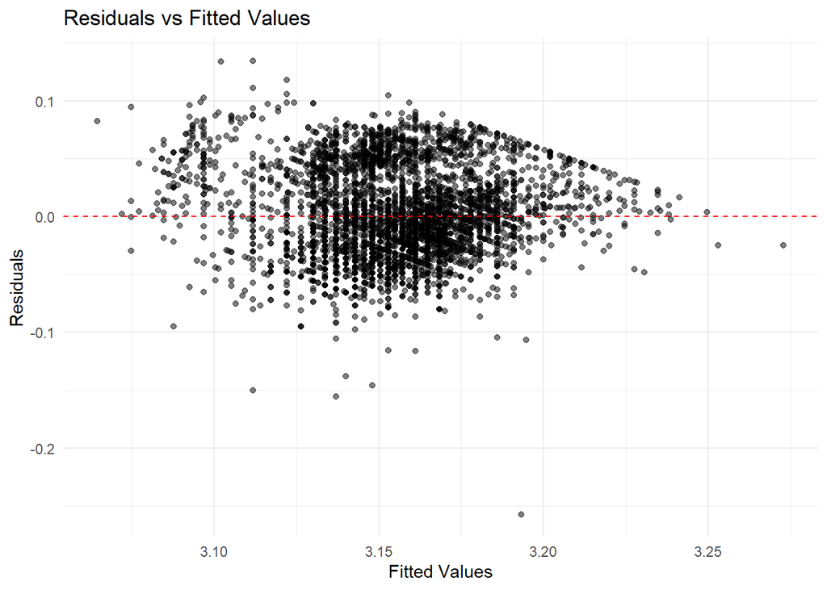

```r
# Linear model: transformed rent (Box–Cox) as a function of transformed size
lm_model <- lm(Rent_bc ~ Size_bc, data = df_clean)

# Extract residuals and fitted values
residuals_bc <- residuals(lm_model)
fitted_bc <- fitted(lm_model)

ggplot(df_clean, aes(x = fitted_bc, y = residuals_bc)) +
  geom_point(alpha = 0.5) +
  geom_hline(yintercept = 0, linetype = "dashed", color = "red") +
  labs(
    title = "Residuals vs Fitted Values",
    x = "Fitted Values",
    y = "Residuals"
  ) +
  theme_minimal()
```

In the Residuals vs Fitted plot, the residuals appear more evenly scattered around zero and exhibit less heteroscedasticity than before. The earlier funnel shape (indicating increasing variance with fitted values) has been significantly reduced. Although there is still some mild structure, the spread is far more contained and symmetric. This suggests that the Box–Cox transformation also helped stabilize the variance.

Thus, we verified that these transformations significantly improved the normality of the residuals, stabilized the variance, and are expected to improve the convergence behavior of the Bayesian models.

Finally, as previously stated, we also comvined **BHK** and **Bathroom** to have a variable of the total rooms, due to their high correlation:

```r
df_clean$RoomsTotal <- df_clean$BHK + df_clean$Bathroom
```

# Bayesian Analysis

In this section of the project, we implement various **Hierarchical Bayesian Linear Regression models** to estimate rental prices based on property characteristics. The models will include both fixed and random effects. The fixed effects will include both numerical and categorical features, while the random effects are modeled at the city level, allowing the influence of the predictors on rent to vary by city.

The main objective of this section is to evaluate three models, identify the best performing one, and determine which effects contribute the most to fluctuations in Rent price.

We will examine the parameter estimates of the best-performing model at the end, after performing convergence diagnostics, and comparing all the models using appropriate evaluation metrics.

## First Model

We first developed a simple **hierarchical Bayesian linear regression model**, where the target variable is Rent, modeled as a function of property features (such as Size, Floor, RoomsTotal), as and a city-level random effect.

In this first model we decided to include only the numerical predictors as fixed effects.

The model is defined as:

$$Rent_i \sim \mathcal{N}(\mu_i, \tau^{-1})$$
Where $\mu_i$ is the mean expected value of Rent for observation $i$, defined as the linear combination of fixed and random effects as follows:

$$\mu = \beta_1 + \beta_2 \cdot \text{Size} + \beta_3 \cdot \text{Floor} +
\beta_4 \cdot \text{RoomsTotal} + \text{city_effect}_{\text{City}}$$
And $\tau^{-1}$ is:

$$\tau^{-1} = \sigma^2_{obs} \quad With \quad \sigma_{obs} \sim
\text{Gamma}(1,1)$$

This prior was chosen for $\sigma_{obs}$ for its ability to maintain positive values, reflecting the inherent property of standard deviations.

The coefficients $\beta_1, \beta_2, \beta_3, \beta_4$ represent the fixed effects, while $\text{city_effect}_{\text{City}}$ introduces random variation across cities. All parameters are estimated using Bayesian inference, with the following prior distributions:

- $\beta_1 - \beta_4$ : Normal(0,1), we assume that most effects are small, but allowing for the possibility of larger effects.
- city_effect_raw :A Normal(0,0.01) prior was chosen to express weak prior information but more variance than the betas.
- sd_city: Gamma(1, 1) prior for the standard deviation of city effects, chosen to be weakly informative and strictly positive, like $\sigma_{obs}$.
- y_rep: Normal($\mu_i$,$\sigma^2_{obs}$) Posterior predictive simulations used for model checking

To improve model stability and interpretability, we distinguish between city_effect_raw and city_effect: the first is an initial random draw for each city, centered around 0. Then, we subtract the mean of the raw effects to ensure the city-level terms do not shift the global intercept. Then, we scale the centered effects by sd_city, allowing the model to learn the actual variation across cities from the data.

```r
model_string_rental <- "
model {
  for (i in 1:N) {
    Rent[i] ~ dnorm(mu[i], tau_obs)
    y_rep[i] ~ dnorm(mu[i], tau_obs)

    mu[i] <- beta[1] +
             beta[2] * Size[i] +
             beta[3] * Floor[i] +
             beta[4] * RoomsTotal[i] +
             city_effect[City[i]]
  }

  beta[1] ~ dnorm(0, 1)
  beta[2] ~ dnorm(0, 1)
  beta[3] ~ dnorm(0, 1)
  beta[4] ~ dnorm(0, 1)

  for (c in 1:C) {
    city_effect_raw[c] ~ dnorm(0, 0.01)
  }

  avg_raw <- sum(city_effect_raw[1:C]) / C

  for (c in 1:C) {
    city_effect[c] <- (city_effect_raw[c] - avg_raw) * sd_city
  }

  sd_city ~ dgamma(1, 1)
  sigma_obs ~ dgamma(1,1)
  tau_obs <- pow(sigma_obs, -2)
}
"

jags_data <- list(
  N = nrow(df_clean),
  C = length(unique(df_clean$City)),
  RoomsTotal = df_clean$RoomsTotal,
  Size = df_clean$Size_bc,
  Rent = df_clean$Rent_bc,
  Floor = as.numeric(df_clean$Floor),
  City = as.numeric(factor(df_clean$City)),
  y_rep = rep(NA, nrow(df_clean))
)

# we initialize only city_effect_raw, because city_effect is derived
inits <- function() {
  list(
    beta = rnorm(4, 0, 1),
    sd_city = rgamma(1, 1, 1),
    sigma_obs = rgamma(1, 1, 1),
    city_effect_raw = rnorm(jags_data$C, 0, 1)

  )
}
```

### Execution

Let’s execute the model:

```r
# Parameters to monitor
params <- c("beta", "sd_city", "sigma_obs", "city_effect", "y_rep")

# Build and run the model
jags_model <- jags.model(
  textConnection(model_string_rental),
  data = jags_data,
  inits = inits,
  n.chains = 3
)
# Burn-in
update(jags_model, n.iter = 1000)

# Sampling
samples <- coda.samples(
  model = jags_model,
  variable.names = params,
  n.iter = 5000
)
```

### Model summary and evaluation

We start with the Posterior Predictive check. Posterior Predictive Check (PPC) is a fundamental tool in Bayesian analysis used to evaluate how well a model reproduces the observed data. In this case, the posterior predictive check plot compares the density of the observed rent data (in dark blue) with the model’s predictions (in light blue).

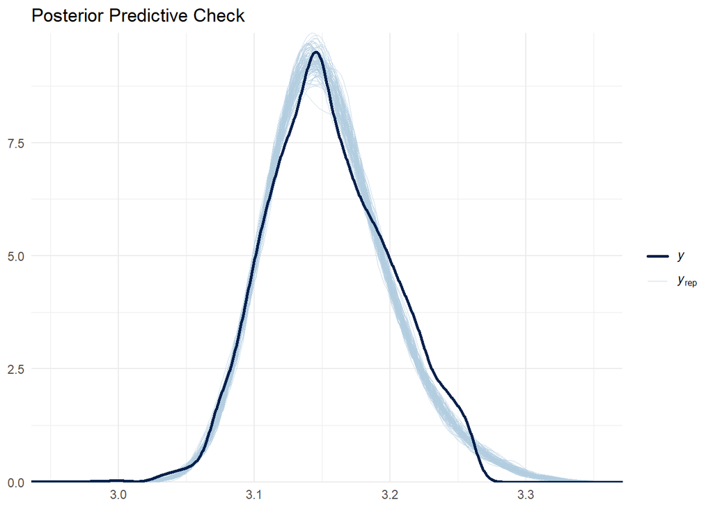

```r
# Extracting the matrix of samples from the chain
samples_matrix <- as.matrix(samples)
y_rep_idx <- grep("^y_rep\\[", colnames(samples_matrix))
y_rep_samples <- samples_matrix[, y_rep_idx]

# Compute predictive mean for each observation
y_rep_mean <- colMeans(y_rep_samples)

# Use the original Rent variable
observed <- df_clean$Rent_bc

# Only 100 simulations for readability
color_scheme_set("blue")
ppc_1 <- ppc_dens_overlay(y = observed, yrep = y_rep_samples[1:100, ]) +
  ggtitle("Posterior Predictive Check") +
  theme_minimal()

ppc_1
```

```r
# Summary statistics
cat("Observed mean:", mean(observed), "\n", "Predicted mean:", mean(y_rep_mean), "\n", "Observed SD:", sd(observed), "\n", "Predicted SD:", sd(y_rep_mean), "\n")
```

```
## Observed mean: 3.154638
##  Predicted mean: 3.154638
##  Observed SD: 0.04489442
##  Predicted SD: 0.03861829
```

We also compare the mean and standard deviation of the predicted data and the observed data. The values for the mean are nearly identical, showing that the model accurately captures the central tendency of the target variable. On the other hand, the predicted variance is slightly narrower than the observed one, suggesting that the model may be underestimating the variability of the data.

After the posterior predictive checks, we performed a second sampling step without y_rep to keep the analysis clean and efficient. Since y_rep includes one value per observation, it would otherwise clutter the output in summaries and traceplots:

```r
params_diag <- c("beta", "sd_city", "sigma_obs", "city_effect")

# Re-sampling without y_rep to avoid cluttering analyses
samples_diag <- coda.samples(jags_model, variable.names = params_diag, n.iter = 5000)

# DIC calculation
dic_result <- dic.samples(jags_model, n.iter = 5000, type = "pD")
mean_deviance <- mean(dic_result$deviance)
mean_penalty <- mean(dic_result$penalty)
dic_1 <- mean_deviance + mean_penalty

print(paste("DIC value for the first model:", round(dic_1, 5)))
```

```
## [1] "DIC value for the first model: -4.71246"
```

We will use the DIC value for comparison of the models after all the analyeses on all the models.

### Convergence Diagnostics

*Traceplot*

For the evaluation of the MCMC convergence **Traceplots**, **Density plots**, **autocorrelation**, **Rhat** and **ESS** from the model summary were used.

Trace plots are another essential tool for assessing the convergence of Markov Chain Monte Carlo chains in Bayesian models: they display the trends of multiple MCMC chains with the number of iteration on the x-axis and the value of the beta coefficient on the y-axis, helping to identify potential convergence issues.

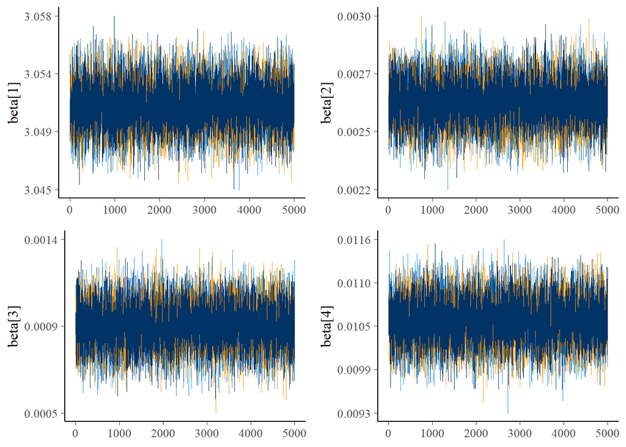

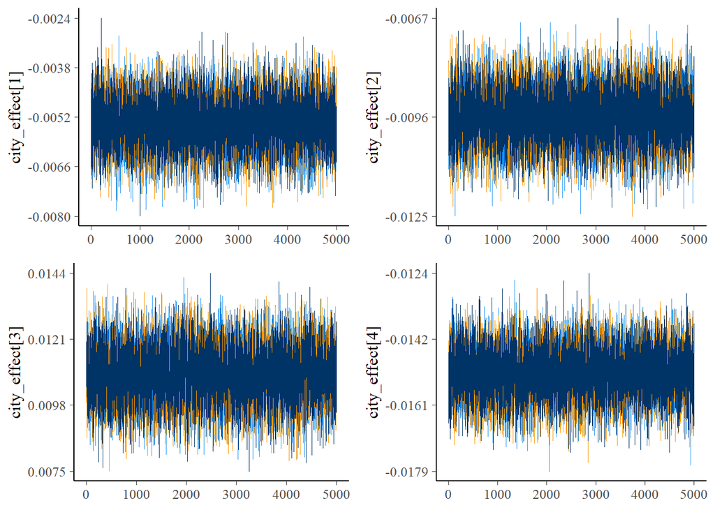

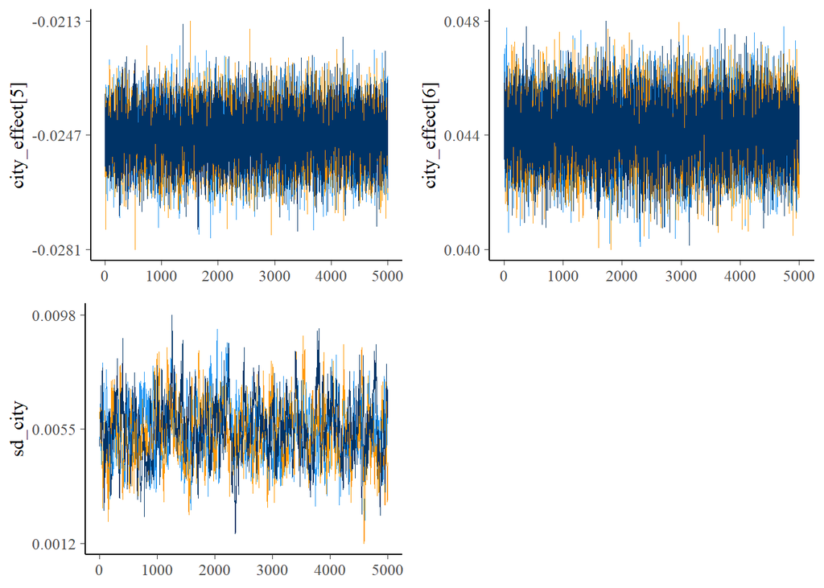

```r
# Convert samples to matrix
samples_matrix <- as.matrix(samples_diag)

# Extract all parameter names
all_params <- colnames(samples_matrix)

# Select only relevant parameters for traceplot
params <- all_params[grepl("beta|sd_city|city_effect", all_params)]
chain_colors <- c("#2196F3", "#ff9800", "#003366")

for (i in seq(1, length(params), by = 4)) {
  end <- min(i + 3, length(params))
  param_subset <- params[i:end]

  traceplot <- mcmc_trace(samples_diag, pars = param_subset) + scale_color_manual(values = chain_colors) + theme(legend.position = "none")
  print(traceplot)
}
```

We can observe that the 3 chains result in 3 overlapping trace plots. The fact that the plots for each coefficient have similar trends indicates that the chains are converging to the same posterior stationary distribution, suggesting robust results from our Bayesian model and the frequent crossing over of chains indicates good mixing, suggesting that the MCMC sampler is exploring the parameter space efficiently.

*Density plot*

Another widely used tool, complementary to trace plots, is the density plot, which shows the posterior probability distribution of the predictor parameters.

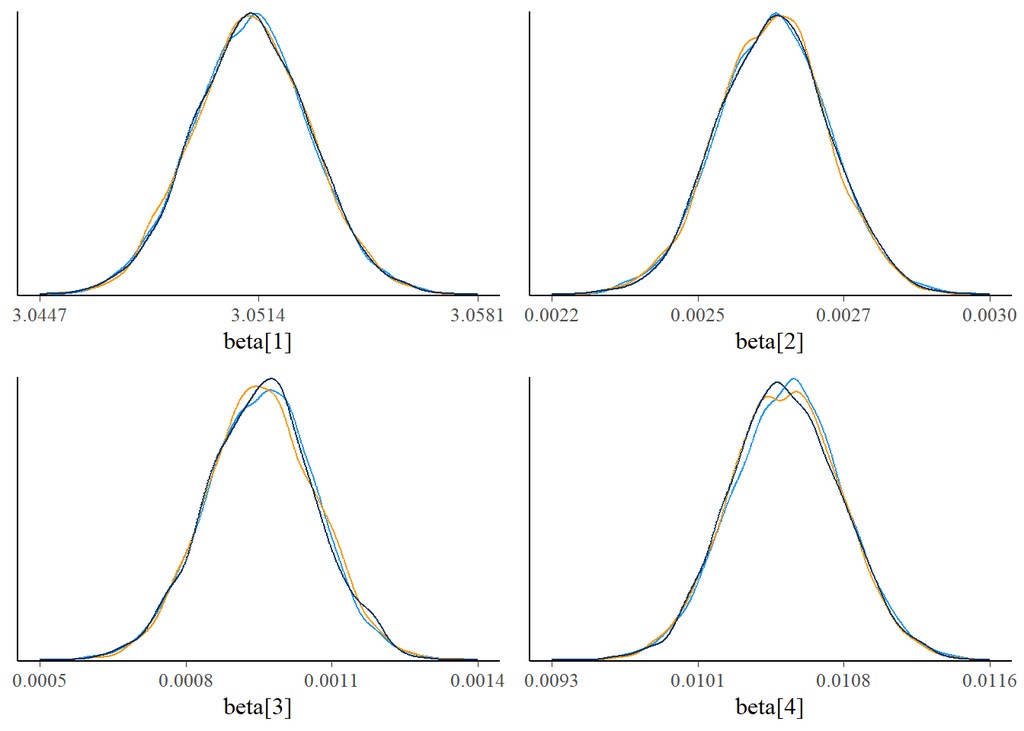

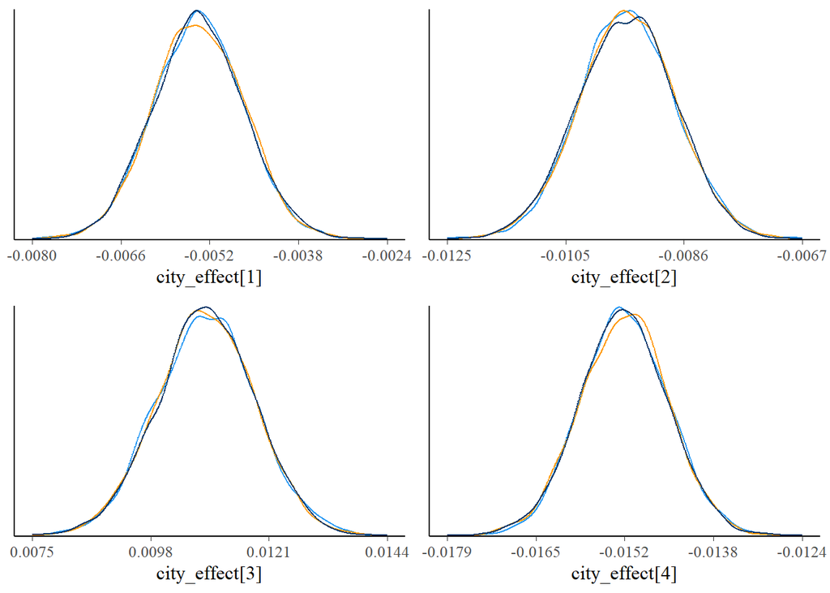

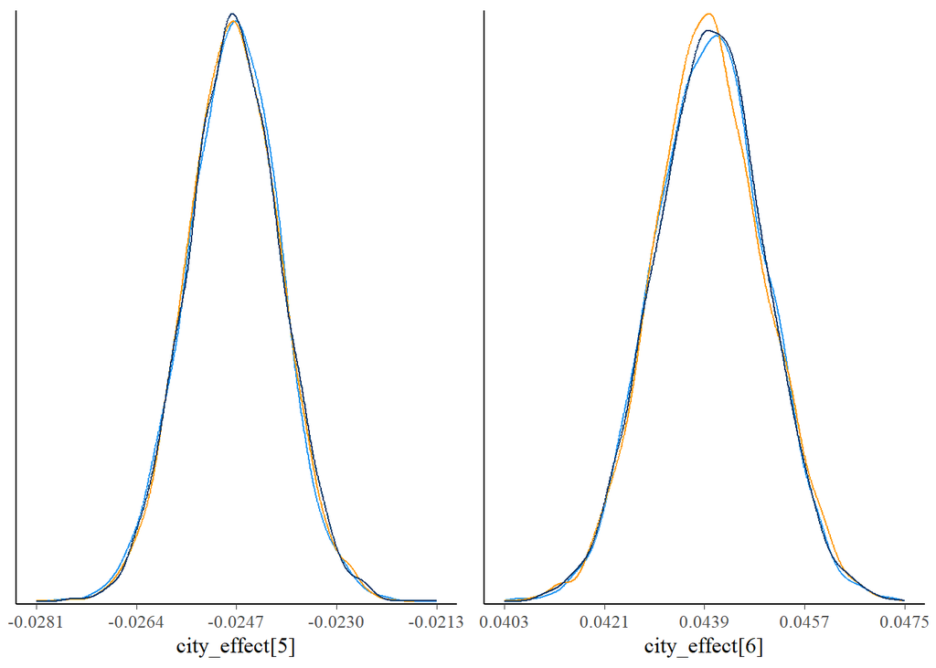

```r
params2 <- all_params[grepl("beta|city_effect", all_params)]

# Plotting Density plots
for (i in seq(1, length(params2), by = 4)) {
  end <- min(i + 3, length(params2))
  param_subset <- params2[i:end]

  density_plot <- mcmc_dens_overlay(samples_diag, pars = param_subset) + scale_color_manual(values = chain_colors)  + theme(legend.position = "none")
  print(density_plot)
}
```

In our case, the density plots clearly reveal that all three chains converge to very similar normal distributions, indicating that the MCMC samples are effectively capturing the posterior distribution of the parameters.

*Autocorrelation plot*

Another widely used diagnostic is the autocorrelation plot, which shows how much each MCMC sample depends on previous ones. High autocorrelation indicates poor mixing and slow exploration of the posterior distribution.

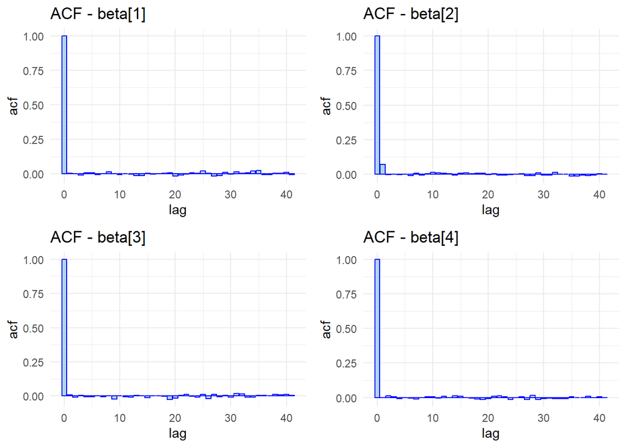

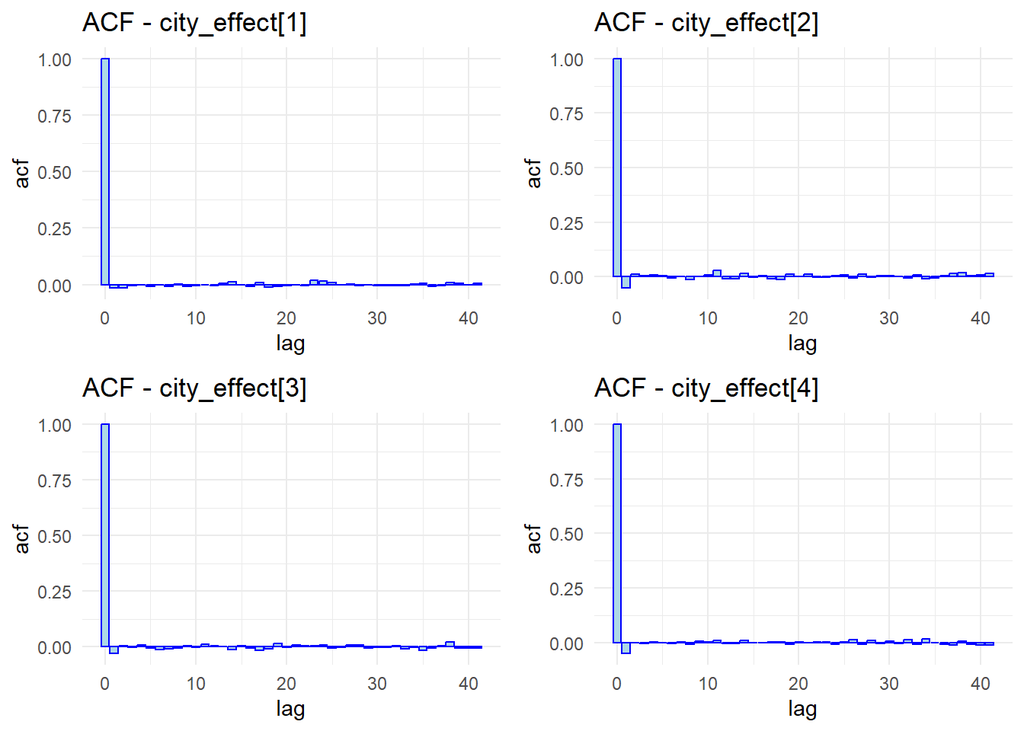

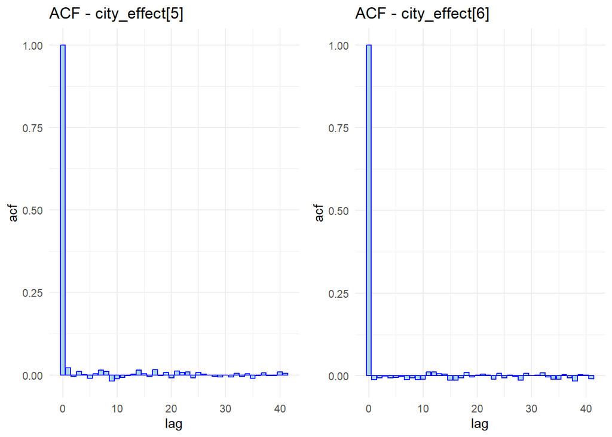

```r
samples_matrix <- as.matrix(sample_diag)

# Autocorrelation Plots
for (i in seq(1, length(params2), by = 4)) {
  end <- min(i + 3, length(params2))
  param_subset <- params2[i:end]

  plots <- list()

  for (p in param_subset) {
    p_samples <- samples_matrix[, p]
    acf_vals <- acf(p_samples, plot = FALSE)
    acf_df <- with(acf_vals, data.frame(lag, acf))

    g <- ggplot(acf_df, aes(x = lag, y = acf)) +
      geom_bar(stat = "identity", fill = "lightblue", color = "blue") +
      labs(title = paste("ACF -", p)) +
      theme_minimal(base_size = 11)

    plots[[p]] <- g
  }

  grid.arrange(grobs = plots, ncol = 2)
}
```

In our case, the autocorrelation drops off quickly across lags for all parameters, suggesting that the chains are mixing well and providing effectively independent samples.

**ESS and R-Hat**

To further assess convergence and sampling efficiency, we computed key diagnostic statistics: R-hat, ess_bulk and ess_tail. **R-hat**, also known as Gelman-Rubin diagnostic, is a statistic tool used in Markov Chain Monte Carlo (MCMC) to evaluate convergence of the chains: when the value of R-hat is close to 1, it indicates that the chains converged to the same stationary target distribution. Meanwhile, **ESS** measures how many independent samples would be equivalent to the correlated samples obtained: when autocorrelation increases, ESS decreases, according to the formula:

$$N_{eff} = \frac{N}{1 + 2\sum_{k =
-\infty}^{\infty}\rho_k}$$
where $N$ is the total number of samples and $\rho_k$ is the autocorrelation at lag $k$ between 2 successive samples.

```r
samples_matrix <- as.matrix(sample_diag)

posterior_samples <- as_draws_df(samples_matrix)

# Print only the relevant stats for convergence analysis
summary_stats <- summarize_draws(posterior_samples, "rhat", "ess_bulk", "ess_tail")

print(summary_stats, n = Inf)
```

```
## # A tibble: 12 × 4
##    variable        rhat ess_bulk ess_tail
##    <chr>          <dbl>    <dbl>    <dbl>
##  1 beta[1]         1.00   14853.   14254.
##  2 beta[2]         1.00   13138.   14534.
##  3 beta[3]         1.00   14738.   14491.
##  4 beta[4]         1.00   14511.   14821.
##  5 city_effect[1]  1.00   15485.   14897.
##  6 city_effect[2]  1.00   15765.   15279.
##  7 city_effect[3]  1.00   15787.   15066.
##  8 city_effect[4]  1.00   16703.   15291.
##  9 city_effect[5]  1.00   14214.   14253.
## 10 city_effect[6]  1.00   15373.   15140.
## 11 sd_city         1.00     511.     947.
## 12 sigma_obs       1.00    9284.    9208.
```

In our case, all parameters showed satisfactory values, confirming the stability and efficiency of the MCMC sampling process.

## Second Model

```r
# To clean the spaces and non-alphanumeric characters
clean_levels <- function(x) {
  x <- gsub("[^A-Za-z0-9]", "_", x)
  x <- gsub("_+", "_", x)
  x <- gsub("^_|_$", "", x)
  return(x)
}

# Converting to factor before transforming in binary variables
df_clean$Furnishing.Status <- factor(clean_levels(df_clean$Furnishing.Status))
df_clean$Tenant.Preferred <- factor(clean_levels(df_clean$Tenant.Preferred))
df_clean$Area.Type <- factor(clean_levels(df_clean$Area.Type))
df_clean$Point.of.Contact <- factor(clean_levels(df_clean$Point.of.Contact))
```

After cleaning, we converted the categorical variables into **dummy variables** using the dummyVars() function. This produces N−1 binary columns for each categorical variable with N levels.

```r
categorical_vars <- df_clean[, c("Furnishing.Status", "Tenant.Preferred", "Area.Type", "Point.of.Contact")]

# Transforming the variables into binary variables
dummy_model <- dummyVars(~ ., data = categorical_vars, fullRank = TRUE)
dummies_df <- as.data.frame(predict(dummy_model, newdata = categorical_vars))
```

```r
model_string_rental2 <- "
model {
  for (i in 1:N) {
    Rent[i] ~ dnorm(mu[i], tau_obs)
    y_rep[i] ~ dnorm(mu[i], tau_obs)

    mu[i] <- beta[1] +
             beta[2] * Size[i] +
             beta[3] * Floor[i] +
             beta[4] * RoomsTotal[i] +
             beta[5] * Furnishing1[i] +
             beta[6] * Furnishing2[i] +
             beta[7] * Tenant2[i] +
             beta[8] * Contact1[i] +
             city_effect[City[i]]
  }

  for (j in 1:4) {
    beta[j] ~ dnorm(0, 1)
  }

  for (j in 5:8) {
    beta[j] ~ dnorm(0, 0.01)
  }

  for (c in 1:C) {
    city_effect_raw[c] ~ dnorm(0, 0.01)
  }

  avg_raw <- sum(city_effect_raw[1:C]) / C
  for (c in 1:C) {
    city_effect[c] <- (city_effect_raw[c] - avg_raw) * sd_city
  }

  sd_city ~ dgamma(1, 1)
  sigma_obs ~ dgamma(1, 1)
  tau_obs <- pow(sigma_obs, -2)
}
"

jags_data2 <- list(
  N = nrow(df_clean),
  C = length(unique(df_clean$City)),
  Rent = df_clean$Rent_bc,
  Size = df_clean$Size_bc,
  Floor = df_clean$Floor,
  RoomsTotal = df_clean$RoomsTotal,
  Furnishing1 = dummies_df$Furnishing.Status.Semi_Furnished,
  Furnishing2 = dummies_df$Furnishing.Status.Unfurnished,
  #Tenant1 = dummies_df$Tenant.Preferred.Bachelors_Family,
  Tenant2 = dummies_df$Tenant.Preferred.Family,
  #AreaType1 = dummies_df$Area.Type.Carpet_Area,
  #AreaType2 = dummies_df$Area.Type.Super_Area,
  Contact1 = dummies_df$Point.of.Contact.Contact_Owner,
  #Contact2 = dummies_df$Point.of.Contact.Contact_Builder,
  City = as.numeric(factor(df_clean$City)),
  y_rep = rep(NA, nrow(df_clean))
)

inits2 <- function() {
  list(
    beta = rnorm(8, 0, 1),
    sd_city = rgamma(1, 1, 1),
    sigma_obs = rgamma(1, 1, 1),
    city_effect_raw = rnorm(jags_data2$C, 0, 1)
  )
}
```

### Execution

Let’s execute the second model:

```r
# Parameters to monitor
params <- c("beta", "sd_city", "sigma_obs", "city_effect", "y_rep")

# Build and run the model
jags_model <- jags.model(
  textConnection(model_string_rental2),
  data = jags_data2,
  inits = inits2,
  n.chains = 3
)
# Burn-in
update(jags_model, n.iter = 1000)

# Sampling
samples <- coda.samples(
  model = jags_model,
  variable.names = params,
  n.iter = 5000
)
```

### Model summary and evaluation

We check for the second model the posterior predictive check:

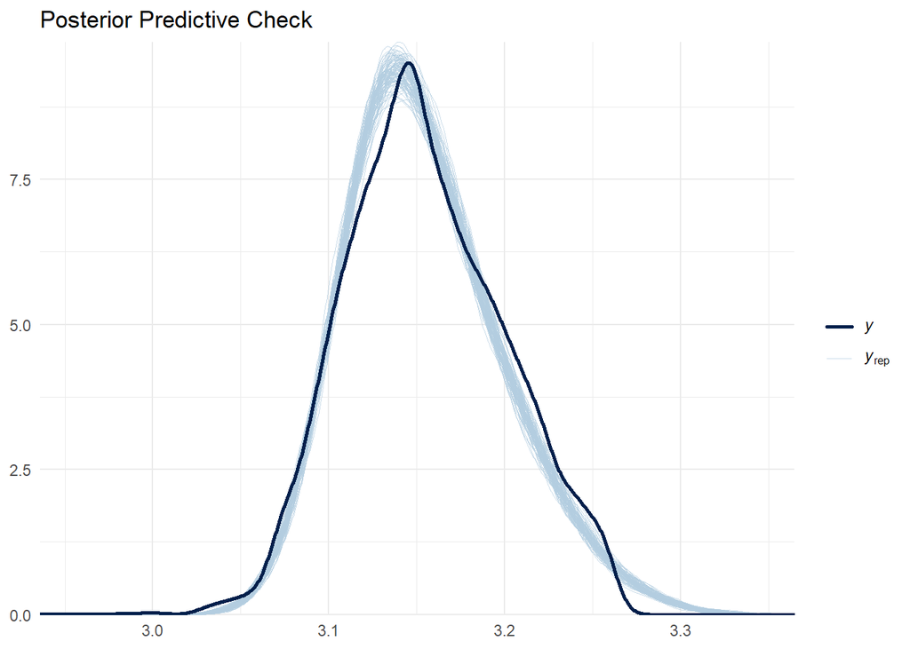

```r
# Extracting the matrix of samples from the chain
samples_matrix <- as.matrix(samples)
y_rep_idx <- grep("^y_rep\\[", colnames(samples_matrix))
y_rep_samples <- samples_matrix[, y_rep_idx]

# Compute predictive mean for each observation
y_rep_mean <- colMeans(y_rep_samples)

# Use the original Rent variable
observed <- df_clean$Rent_bc

# Only the first 100 predictions to not clutter the graph
color_scheme_set("blue")
ppc_2 <- ppc_dens_overlay(y = observed, yrep = y_rep_samples[1:100, ]) +
  ggtitle("Posterior Predictive Check") +
  theme_minimal()

ppc_2
```

From the plot, we immediately notice an improved fit in the upper range of the rent distribution. This suggests that the inclusion of categorical variables, along with the adjustment to the priors, may have enabled the model to make more accurate predictions for higher rent values.

```r
# Summary statistics
cat("Observed mean:", mean(observed), "\n", "Predicted mean:", mean(y_rep_mean), "\n", "Observed SD:", sd(observed), "\n", "Predicted SD:", sd(y_rep_mean), "\n")
```

```
## Observed mean: 3.154638
##  Predicted mean: 3.15464
##  Observed SD: 0.04489442
##  Predicted SD: 0.0394967
```

The comparison of the observed and predicted Mean and SD further confirm the improvement of the model, being closer to the observed values.

```r
# Re-sampling without y_rep to avoid cluttering analyses
samples_diag <- coda.samples(jags_model, variable.names = params_diag, n.iter = 5000)

# DIC Calculation
dic_result <- dic.samples(jags_model, n.iter = 5000, type = "pD")
mean_deviance <- mean(dic_result$deviance)
mean_penalty <- mean(dic_result$penalty)
dic_2 <- mean_deviance + mean_penalty

print(paste("DIC value for the second model:", round(dic_2, 5)))
```

```
## [1] "DIC value for the second model: -4.85196"
```

The DIC value is definitely lower compared to the previous model (-4.7124), further confirming the improvement. Now let’s check the convergence.

### Convergence Diagnostics

For the evaluation of the MCMC convergence Traceplot, density plots, autocorrelation, Rhat and ESS from the model summary were used, as for the previous model.

*Traceplot*

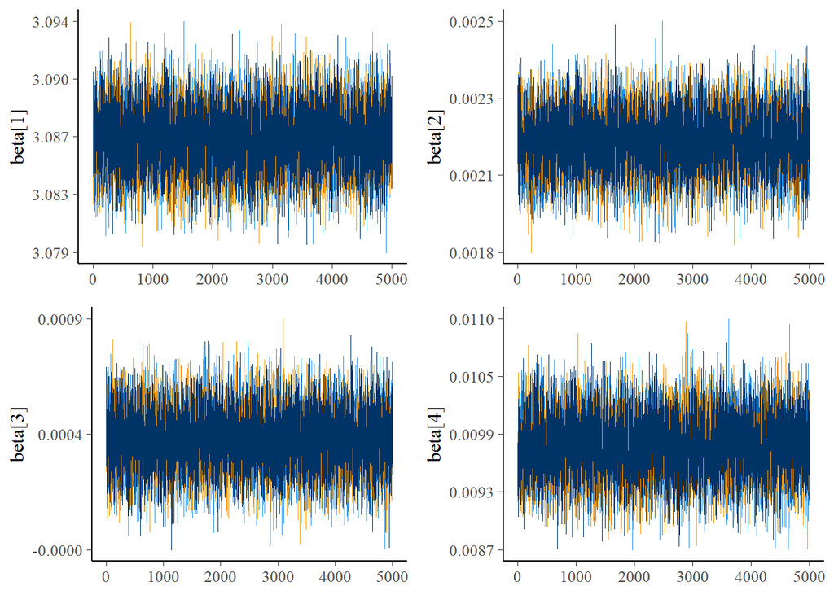

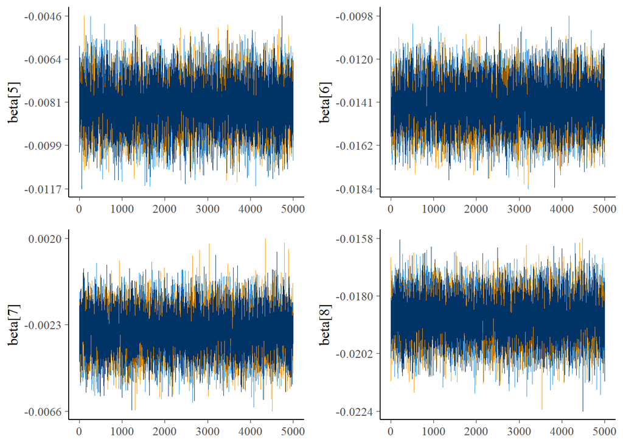

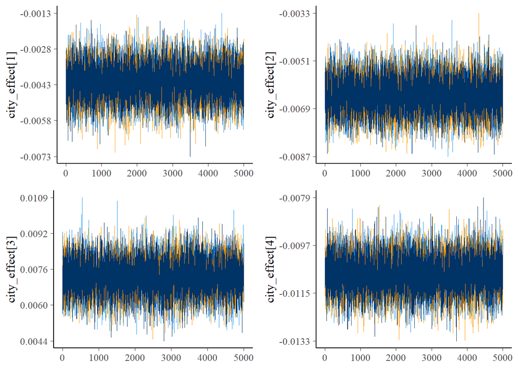

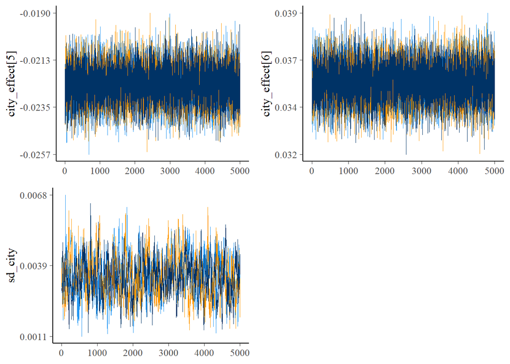

```r
# Convert samples to matrix
samples_matrix <- as.matrix(samples_diag)
all_params <- colnames(samples_matrix)

# Select only relevant parameters for traceplot
params <- all_params[grepl("beta|sd_city|city_effect", all_params)]
chain_colors <- c("#2196F3", "#ff9800", "#003366")

# Plot traceplots
for (i in seq(1, length(params), by = 4)) {
  end <- min(i + 3, length(params))
  param_subset <- params[i:end]

  traceplot <- mcmc_trace(samples_diag, pars = param_subset) + scale_color_manual(values = chain_colors) + theme(legend.position = "none")
  print(traceplot)
}
```

The conclusions we can draw from these traceplots are the same as the first model, in fact, the trace plots indicate that the MCMC chains for the Bayesian hierarchical model have converged well, with good mixing and stationarity.

*Density plot*

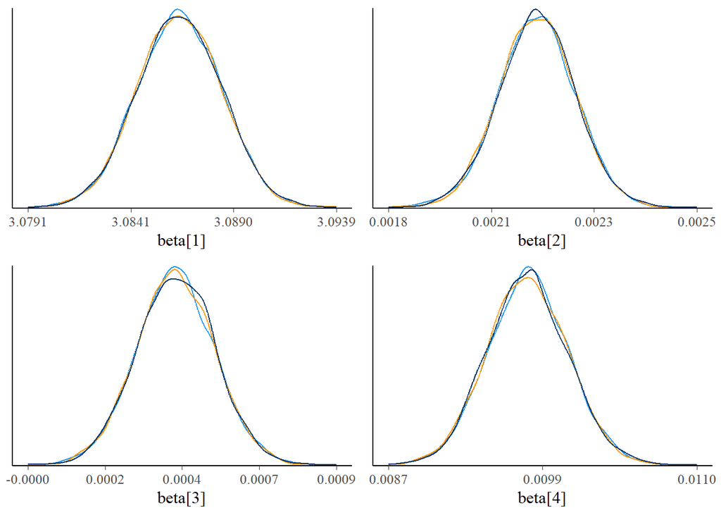

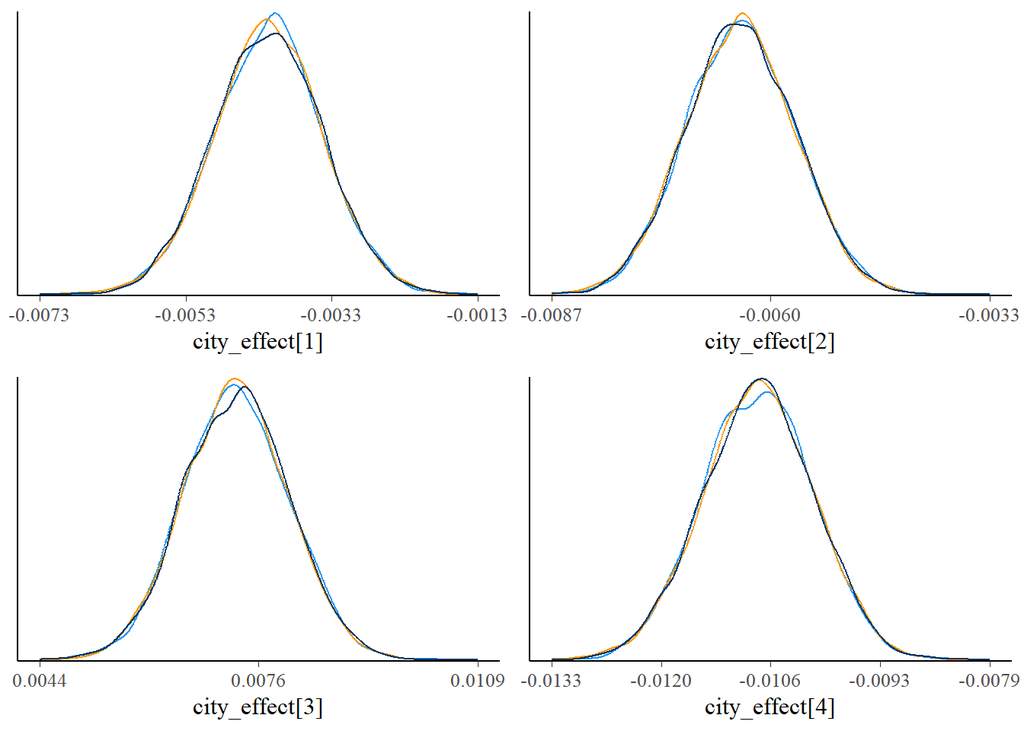

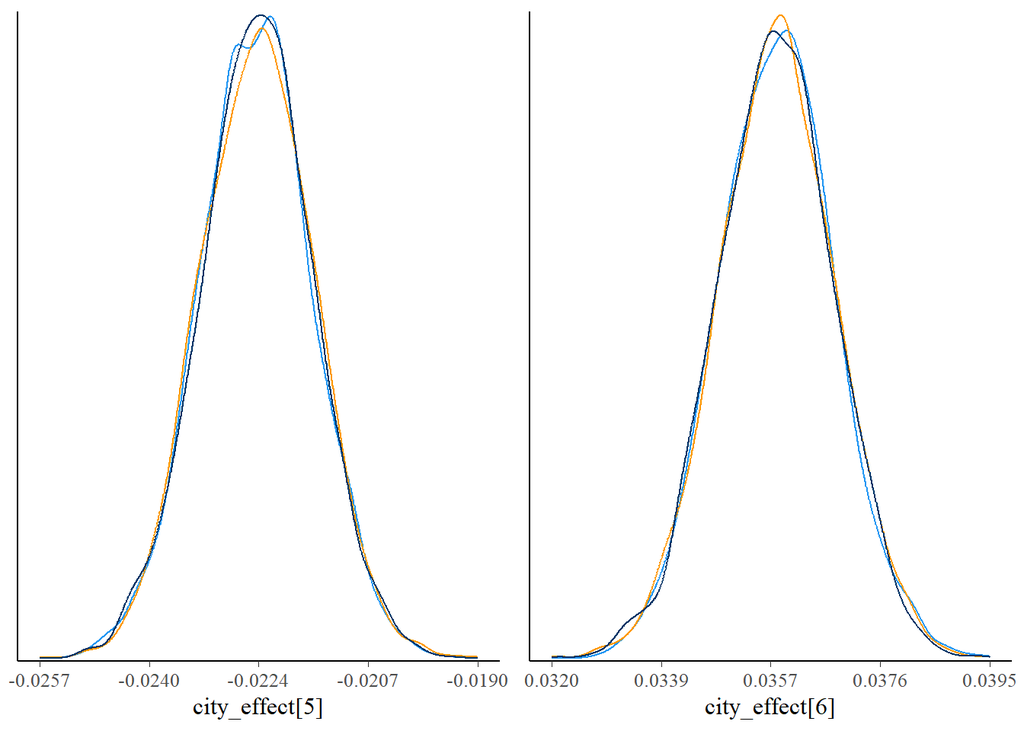

```r
params2 <- all_params[grepl("beta|city_effect", all_params)]

# Plotting Density plots
for (i in seq(1, length(params2), by = 4)) {
  end <- min(i + 3, length(params2))
  param_subset <- params2[i:end]

  density_plot <- mcmc_dens_overlay(samples_diag, pars = param_subset) + scale_color_manual(values = chain_colors) + theme(legend.position = "none")
  print(density_plot)
}
```

For the second model, the density plots reveal that all three chains converge to very similar normal distributions, indicating that the MCMC samples are effectively capturing the posterior distribution of the parameters and suggesting well-defined and stable parameter estimates.

*Autocorrelation plot*

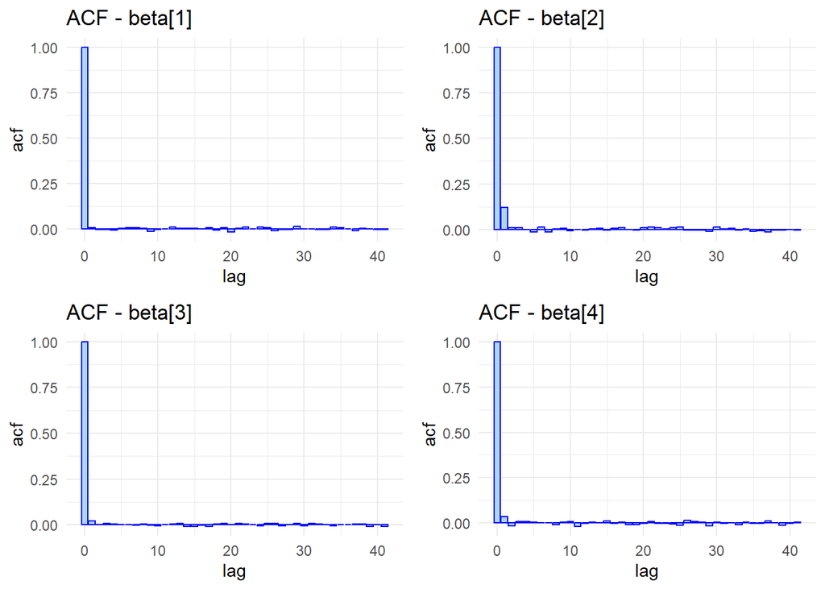

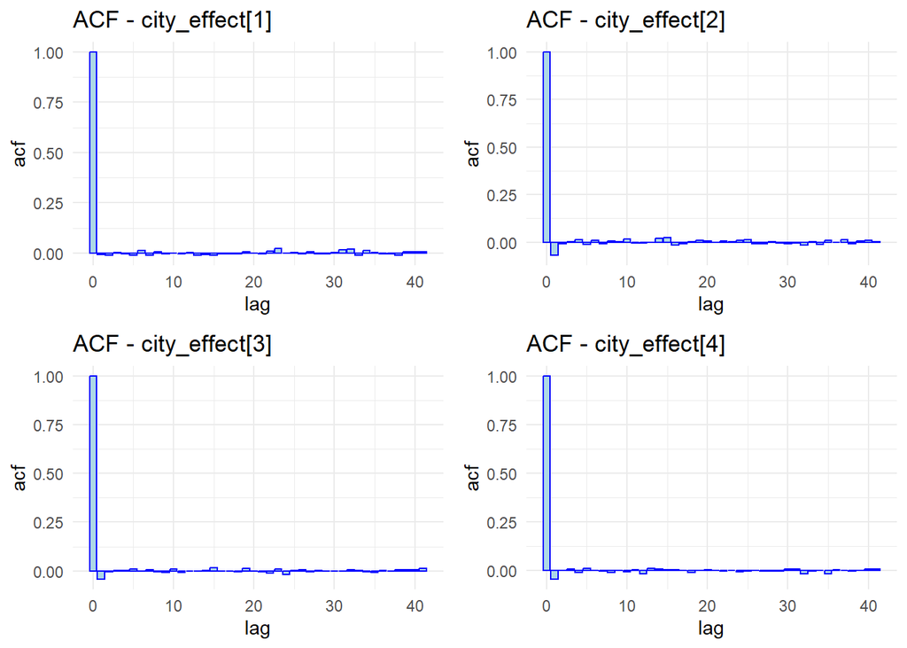

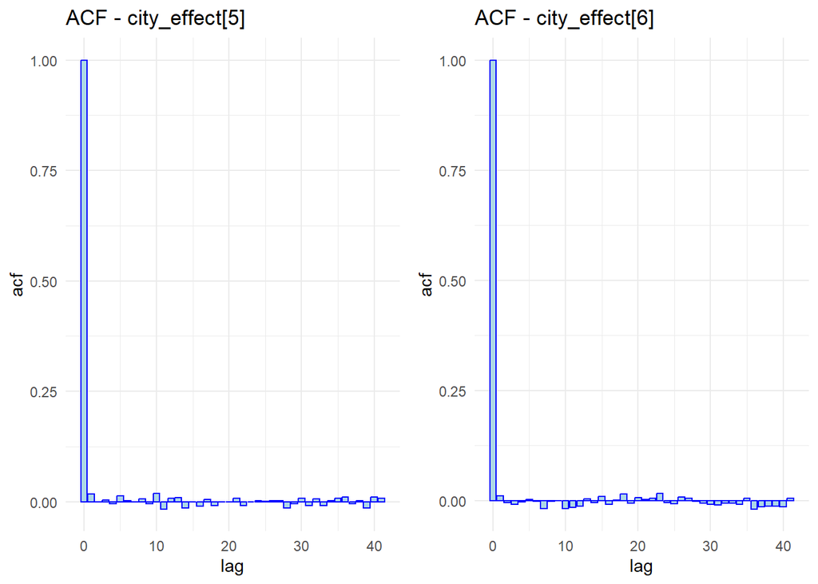

```r
samples_matrix <- as.matrix(sample_diag)

# Autocorrelation Plots
for (i in seq(1, length(params2), by = 4)) {
  end <- min(i + 3, length(params2))
  param_subset <- params2[i:end]

  plots <- list()

  for (p in param_subset) {
    p_samples <- samples_matrix[, p]
    acf_vals <- acf(p_samples, plot = FALSE)
    acf_df <- with(acf_vals, data.frame(lag, acf))

    g <- ggplot(acf_df, aes(x = lag, y = acf)) +
      geom_bar(stat = "identity", fill = "lightblue", color = "blue") +
      labs(title = paste("ACF -", p)) +
      theme_minimal(base_size = 11)

    plots[[p]] <- g
  }

  grid.arrange(grobs = plots, ncol = 2)
}
```

**ESS and R-Hat**

```r
samples_matrix <- as.matrix(sample_diag)

posterior_samples <- as_draws_df(samples_matrix)

# Print only the relevant stats for convergence analysis
summary_stats <- summarize_draws(posterior_samples, "rhat", "ess_bulk", "ess_tail")

print(summary_stats, n = Inf)
```

```
## # A tibble: 16 × 4
##    variable        rhat ess_bulk ess_tail
##    <chr>          <dbl>    <dbl>    <dbl>
##  1 beta[1]         1.00   14887.   14381.
##  2 beta[2]         1.00   11773.   13980.
##  3 beta[3]         1.00   13828.   14088.
##  4 beta[4]         1.00   14046.   14613.
##  5 beta[5]         1.00   14637.   14421.
##  6 beta[6]         1.00   14760.   14983.
##  7 beta[7]         1.00   14427.   14436.
##  8 beta[8]         1.00   15215.   14381.
##  9 city_effect[1]  1.00   15204.   14633.
## 10 city_effect[2]  1.00   17428.   15194.
## 11 city_effect[3]  1.00   16436.   15118.
## 12 city_effect[4]  1.00   16210.   15197.
## 13 city_effect[5]  1.00   14203.   13961.
## 14 city_effect[6]  1.00   14676.   14817.
## 15 sd_city         1.01     482.    1040.
## 16 sigma_obs       1.00    9851.    8912.
```

Finally, the second model also shows excellent R-Hat values and ESS across all parameters, confirming the convergence of the model.

## Third Model

For the third model, we created new variables by combining existing features, with the goal of capturing additional structure in the data and identifying potentially significant interactions. Specifically, the newly derived variables include:

- **OwnerLowQuality**: A binary variable indicating properties that may be considered lower quality. It has value 1 if the property is *unfurnished*, has *2 or fewer total rooms* and is listed directly by the *owner*.
- **IsHighFloor**: Indicates whether the property is located on a high floor, defined as being in the top *25% of the floor distribution*.
- **Furnished_Big**: Flags properties that are both *furnished* and *larger than the median size*. These may represent higher-end listings and could correlate with increased rental value.
- **AgentFurnished**: Marks properties that are *furnished* and managed by an *agent*, rather than directly by the owner. This may reflect more professional property setups and potentially higher prices.

```r
# Creation of new variables derived from pre-existing variables

df_clean$OwnerLowQuality <- ifelse(df_clean$Point.of.Contact == "Contact_Owner" &
                                   df_clean$Furnishing.Status == "Unfurnished" &
                                   df_clean$RoomsTotal <= 2, 1, 0)

df_clean$Is_HighFloor <- ifelse(df_clean$Floor >= quantile(df_clean$Floor, 0.75, na.rm = TRUE), 1, 0)

df_clean$Furnished_Big <- ifelse(df_clean$Furnishing.Status == "Furnished" & df_clean$Size > median(df_clean$Size, na.rm = TRUE), 1, 0)

df_clean$AgentFurnished <- ifelse(df_clean$Point.of.Contact != "Contact_Owner" &
                                   df_clean$Furnishing.Status == "Furnished", 1, 0)
```

These new variables are included in the model as fixed effects, with the same prior as the other regression coefficients, that is $\mathcal{N}(0,0.01)$.

```r
model_string_rental_final <- "
model {
  for (i in 1:N) {
    Rent[i] ~ dnorm(mu[i], tau_obs)
    y_rep[i] ~ dnorm(mu[i], tau_obs)

    mu[i] <- beta[1] +
             beta[2] * Size[i] +
             beta[3] * Floor[i] +
             beta[4] * RoomsTotal[i] +
             beta[5] * Furnishing1[i] +
             beta[6] * Furnishing2[i] +
             beta[7] * Tenant2[i] +
             beta[8] * Contact1[i] +
             beta[9] * OwnerLowQuality[i] +
             beta[10] * Is_HighFloor[i] +
             beta[11] * Furnished_Big[i] +
             beta[12] * AgentFurnished[i] +
             city_effect[City[i]]
  }

  for (j in 1:4) {
    beta[j] ~ dnorm(0, 1)
  }

  for (j in 5:12) {
    beta[j] ~ dnorm(0, 0.01)
  }

  for (c in 1:C) {
    city_effect_raw[c] ~ dnorm(0, 0.01)
  }

  avg_raw <- sum(city_effect_raw[1:C]) / C
  for (c in 1:C) {
    city_effect[c] <- (city_effect_raw[c] - avg_raw) * sd_city
  }

  sd_city ~ dgamma(1, 1)
  sigma_obs ~ dgamma(1, 1)
  tau_obs <- pow(sigma_obs, -2)
}
"

jags_data3 <- list(
  N = nrow(df_clean),
  C = length(unique(df_clean$City)),
  Rent = df_clean$Rent_bc,
  Size = df_clean$Size_bc,
  Floor = df_clean$Floor,
  RoomsTotal = df_clean$RoomsTotal,
  Furnishing1 = dummies_df$Furnishing.Status.Semi_Furnished,
  Furnishing2 = dummies_df$Furnishing.Status.Unfurnished,
  Tenant2 = dummies_df$Tenant.Preferred.Family,
  Contact1 = dummies_df$Point.of.Contact.Contact_Owner,
  OwnerLowQuality = df_clean$OwnerLowQuality,
  Is_HighFloor = df_clean$Is_HighFloor,
  Furnished_Big = df_clean$Furnished_Big,
  AgentFurnished = df_clean$AgentFurnished,
  City = as.numeric(factor(df_clean$City)),
  y_rep = rep(NA, nrow(df_clean))
)

inits3 <- function() {
  list(
    beta = rnorm(12, 0, 1),
    sd_city = rgamma(1, 1, 1),
    sigma_obs = rgamma(1, 1, 1),
    city_effect_raw = rnorm(jags_data3$C, 0, 1)
  )
}
```

### Execution

Let’s execute the final model:

```r
# Parameters to monitor
params <- c("beta", "sd_city", "sigma_obs", "city_effect", "y_rep")

# Build and run the model
jags_model_final <- jags.model(
  textConnection(model_string_rental_final),
  data = jags_data3,
  inits = inits3,
  n.chains = 3
)
# Burn-in
update(jags_model_final, n.iter = 1000)

# Sampling
samples <- coda.samples(
  model = jags_model_final,
  variable.names = params,
  n.iter = 5000
)
```

### Model summary and evaluation

We check for the final model the posterior predictive check:

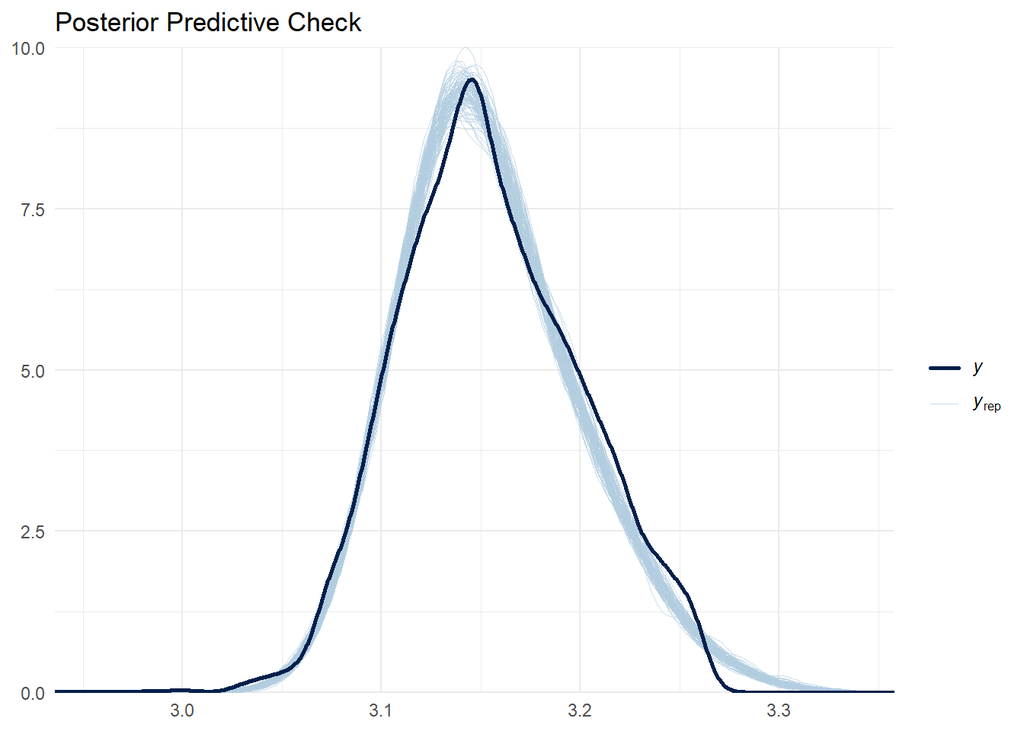

```r
# Extracting the matrix of samples from the chain
samples_matrix <- as.matrix(samples)
y_rep_idx <- grep("^y_rep\\[", colnames(samples_matrix))
y_rep_samples <- samples_matrix[, y_rep_idx]

# Compute predictive mean for each observation
y_rep_mean <- colMeans(y_rep_samples)

# Use the original Rent variable
observed <- df_clean$Rent_bc

# Only the first 100 predictions to not clutter the graph
color_scheme_set("blue")
ppc_3 <- ppc_dens_overlay(y = observed, yrep = y_rep_samples[1:100, ]) +
  ggtitle("Posterior Predictive Check") +
  theme_minimal()

ppc_3
```

From the plot, we notice only a slight improvement from the previous model, in particular in the higher ends of the distribution and in the middle part, around 3.15.

```r
# Summary statistics
cat("Observed mean:", mean(observed), "\n", "Predicted mean:", mean(y_rep_mean), "\n", "Observed SD:", sd(observed), "\n", "Predicted SD:", sd(y_rep_mean), "\n")
```

```
## Observed mean: 3.154638
##  Predicted mean: 3.154634
##  Observed SD: 0.04489442
##  Predicted SD: 0.0395621
```

```r
# Re-sampling without y_rep to avoid cluttering analyses
samples_diag <- coda.samples(jags_model_final, variable.names = params_diag, n.iter = 5000)


# DIC calculation
dic_result <- dic.samples(jags_model_final, n.iter = 5000, type = "pD")
mean_deviance <- mean(dic_result$deviance)
mean_penalty <- mean(dic_result$penalty)
dic_3 <- mean_deviance + mean_penalty

print(paste("DIC value for the third model:", round(dic_3, 5)))
```

```
## [1] "DIC value for the third model: -4.86107"
```

The DIC also improved only slightly from the previous model (-4.851), suggesting that the new variables have improved the model only marginally.